# Seruat

## R Markdown

使用read_delim函数需要载入readr包 如未安装，使用

```r
> BiocManager::install('readr')
```

安装

## 读取数据

### disease组数据

```r
> library(readr)
> disease_barcodes <- read_delim("disease/filtered_feature_bc_matrix/barcodes.tsv.gz",
+                            delim = "\t", escape_double = FALSE,
+                            col_names = FALSE, trim_ws = TRUE)
> disease_features <- read_delim("disease/filtered_feature_bc_matrix/features.tsv.gz",
+                        delim = "\t", escape_double = FALSE,
+                        col_names = FALSE, trim_ws = TRUE)
> disease_matrix <- read.table("disease/filtered_feature_bc_matrix/matrix.mtx.gz", quote="\"", comment.char="%")
> View(disease_matrix)
```

查看数据

```r
> head(disease_barcodes)
```

```
# A tibble: 6 x 1
  X1
  <chr>
1 AAACCTGAGACAAAGG-1
2 AAACCTGAGATGCGAC-1
3 AAACCTGAGCTGGAAC-1
4 AAACCTGAGGATGGTC-1
5 AAACCTGAGTACGTAA-1
6 AAACCTGCAATTGCTG-1
```

```r
> head(disease_features)
```

```
# A tibble: 6 x 3
  X1              X2          X3
  <chr>           <chr>       <chr>
1 ENSG00000243485 MIR1302-2HG Gene Expression
2 ENSG00000237613 FAM138A     Gene Expression
3 ENSG00000186092 OR4F5       Gene Expression
4 ENSG00000238009 AL627309.1  Gene Expression
5 ENSG00000239945 AL627309.3  Gene Expression
6 ENSG00000239906 AL627309.2  Gene Expression
```

```r
> head(disease_matrix)
```

```
     V1    V2       V3
1 36601 11703 15389508
2    15     1        1
3    31     1        2
4    45     1        1
5    60     1        2
6    63     1        1
```

## normal组数据

```r
> normal_barcodes <- read_delim("normal/filtered_feature_bc_matrix/barcodes.tsv.gz",
+                                delim = "\t", escape_double = FALSE,
+                                col_names = FALSE, trim_ws = TRUE)
>
> normal_features <- read_delim("normal/filtered_feature_bc_matrix/features.tsv.gz",
+                                delim = "\t", escape_double = FALSE,
+                                col_names = FALSE, trim_ws = TRUE)
>
> #去除前两行注释
>
> normal_matrix <- read.table("normal/filtered_feature_bc_matrix/matrix.mtx.gz",
+                             quote="\"",
+                             comment.char="%")
```

显示结果

```r
> head(normal_barcodes)
```

```
# A tibble: 6 x 1
  X1
  <chr>
1 AAACCTGAGCCACGTC-1
2 AAACCTGAGGAATTAC-1
3 AAACCTGCAAAGGTGC-1
4 AAACCTGCAACGATGG-1
5 AAACCTGCACATGGGA-1
6 AAACCTGCACTAGTAC-1
```

```r
> head(normal_features)
```

```
# A tibble: 6 x 3
  X1              X2          X3
  <chr>           <chr>       <chr>
1 ENSG00000243485 MIR1302-2HG Gene Expression
2 ENSG00000237613 FAM138A     Gene Expression
3 ENSG00000186092 OR4F5       Gene Expression
4 ENSG00000238009 AL627309.1  Gene Expression
5 ENSG00000239945 AL627309.3  Gene Expression
6 ENSG00000239906 AL627309.2  Gene Expression
```

```r
> head(normal_matrix)
```

```
     V1   V2       V3
1 36601 9711 12407443
2    84    1        1
3    98    1        1
4   144    1        1
5   171    1        6
6   235    1        1
```

## Seurat后续分析

安装Seurat包

```r
> BiocManager::install('Seurat')
```

载入需要的包

```r
> library(Seurat)
> library(dplyr)
> library(Matrix)
```

## 读入数据

### disease输入

```r
> disease <- Read10X(data.dir = "disease/filtered_feature_bc_matrix/")
> dense.size <- object.size(x = as.matrix(x = disease))
> sparse.size <- object.size(x = disease)
```

结果展示

```r
> dense.size
```

```
3430246680 bytes
```

```r
> sparse.size
```

```
188236672 bytes
```

```r
> dense.size / sparse.size
```

```
18.2 bytes
```

### normal输入

```r
> normal <- Read10X(data.dir = "normal/filtered_feature_bc_matrix/")
> dense.size <- object.size(x = as.matrix(x = normal))
> sparse.size <- object.size(x = normal)
```

结果展示

```r
> dense.size
```

```
2846797848 bytes
```

```r
> sparse.size
```

```
152268632 bytes
```

```r
> dense.size / sparse.size
```

```
18.7 bytes
```

## 从原始数据创造Seurat对象

```r
> neurons <- CreateSeuratObject(counts = disease, min.cells = 3, min.genes = 200,  project = "disease")
> neurons
```

```
An object of class Seurat
18226 features across 11703 samples within 1 assay
Active assay: RNA (18226 features, 0 variable features)
```

```r
> mito.genes <- grep(pattern = "^MT-", x = rownames(x=neurons), value = TRUE)
> percent.mito <- Matrix::colSums(neurons[mito.genes, ]) / Matrix::colSums(neurons)
> neurons <- AddMetaData(object = neurons, metadata = percent.mito, col.name = "percent.mito")
```

如果是serat2.0 使用以下语句

```r
> VlnPlot(object = neurons, features = c( "nGene", "nUMI","percent.mito"), ncol = 3)
```

serat3.0 使用以下语句,用它用它

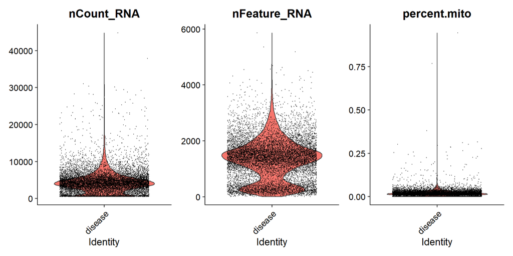

```r
> VlnPlot(object = neurons, features = c( "nCount_RNA", "nFeature_RNA","percent.mito"), ncol = 3)
```

## 展示变量和变量之间的相互关系

FeatureScatter is typically used to visualize feature-feature relationships, but can be used for anything calculated by the object, i.e. columns in object metadata, PC scores etc.

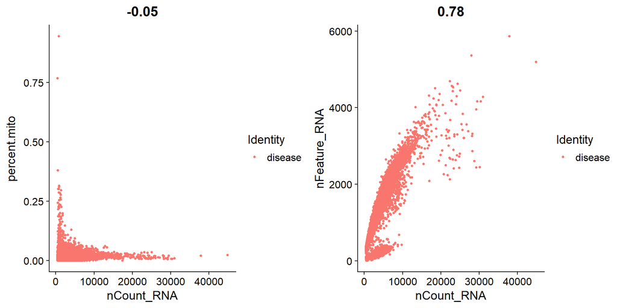

```r
> plot1 <- FeatureScatter(neurons, feature1 ="nCount_RNA", feature2 ="percent.mito")
> plot2 <- FeatureScatter(neurons, feature1 ="nCount_RNA", feature2 ="nFeature_RNA")
> CombinePlots(plots = list(plot1, plot2))
```

## 预处理

```r
> pbmc <- subset(neurons, subset = nFeature_RNA >200& nFeature_RNA <2500& percent.mito <5)
> pbmc <- NormalizeData(pbmc, normalization.method ="LogNormalize", scale.factor =10000)
```

## 识别高度可变的 features (FindVariableFeatures)

```r
> pbmc <- FindVariableFeatures(pbmc, selection.method ="vst", nfeatures =2000)
```

Identify the 10 most highly variable genes 识别十个最显著的基因 plot variable features with and without labels 同时输出图像

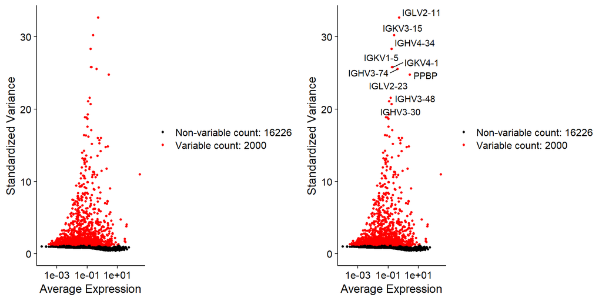

```r
> top10 <- head(VariableFeatures(pbmc),10)
> plot1 <- VariableFeaturePlot(pbmc)
> plot2 <- LabelPoints(plot = plot1, points = top10, repel =TRUE)
>
> CombinePlots(plots = list(plot1, plot2))
```

## 缩放数据

ScaleData即为将变量进行z分数转换，因为PCA默认输入变量服从正态分布

```r
> all.genes <- rownames(pbmc)
> pbmc <- ScaleData(pbmc, features = all.genes)
```

##执行PCA

```r
> pbmc <- RunPCA(pbmc, features = VariableFeatures(object = pbmc))
```

```
PC_ 1
Positive:  PTPRCAP, CD3E, IL32, IL2RG, IFITM1, CD3D, LCK, EVL, PCED1B-AS1, LIME1
       CD3G, IL7R, CD2, GZMM, TRBC2, ZAP70, BIN1, MT-ND4L, SEPTIN1, FCMR
       CD7, LTB, CD247, CXCR4, LDHB, GZMA, RHOH, SKAP1, SPOCK2, CD69
Negative:  LYZ, CST3, IFI30, FCN1, AIF1, TYROBP, S100A9, FTL, S100A8, SPI1
       CTSS, FCER1G, LST1, MNDA, TYMP, CD14, FOS, SERPINA1, CSTA, FTH1
       VCAN, SAT1, TSPO, NCF2, TKT, S100A12, S100A11, LGALS1, NEAT1, COTL1
PC_ 2
Positive:  MALAT1, VIM, S100A6, S100A4, JUNB, CD74, S100A11, S100A10, DUSP1, CRIP1
       CD52, TKT, ZFP36, ANXA1, PTPRCAP, IER2, IFITM1, CTSS, TSPO, LGALS1
       LTB, IL2RG, HLA-DRB1, LY6E, NCF1, CXCR4, MT-ND4L, EVL, TYROBP, CD3E
Negative:  GP9, TUBB1, MPIG6B, CAVIN2, TSC22D1, SPARC, GNG11, PF4, CMTM5, ITGA2B
       TREML1, TMEM40, MYL9, ESAM, PPBP, AP003068.2, PTGS1, BEX3, PF4V1, HIST1H2AC
       ITGB3, C2orf88, HIST1H2BJ, CLU, HIST1H3H, MMD, GRAP2, GP1BB, NRGN, MYLK
PC_ 3
Positive:  ALAS2, HBA1, HBA2, SELENBP1, CA1, HBB, AHSP, HBM, HBD, SLC25A39
       STRADB, EPB42, SLC25A37, FAM210B, HBQ1, SNCA, TUBB2A, SLC4A1, FECH, TRIM58
       TMOD1, DMTN, BPGM, ADIPOR1, BNIP3L, AC130456.3, UBB, GYPB, RNF10, GYPC
Negative:  MALAT1, VIM, S100A4, IFITM2, IFITM1, NKG7, S100A6, CCL5, PRF1, CST7
       GZMA, S100A10, CTSW, IL32, MT-ATP8, CRIP1, CD3E, ANXA1, GZMM, JUNB
       CCND3, CTSC, RAP1B, CD3D, LCK, LY6E, SSR4, EVL, GZMH, ZAP70
PC_ 4
Positive:  CD79A, MS4A1, BANK1, CD79B, LINC00926, HLA-DQA1, IGHM, SPIB, BLK, CD19
       HLA-DRA, NIBAN3, FCRLA, CD74, CD22, RALGPS2, AFF3, HLA-DQB1, P2RX5, HLA-DPA1
       HLA-DPB1, IGHD, BLNK, IGHG2, HLA-DRB5, HLA-DRB1, HLA-DOB, CD40, FCER2, LINC02397
Negative:  S100A4, HBA1, SELENBP1, ALAS2, HBA2, CA1, CD3E, SLC25A37, IL32, AHSP
       HBM, CD3D, FAM210B, ANXA1, HBB, LCK, BLVRB, HBD, GZMM, EPB42
       NKG7, GZMA, CST7, OPTN, PRF1, SNCA, SLC25A39, CD3G, S100A6, HBQ1
PC_ 5
Positive:  MAL, TCF7, CCR7, LEF1, LTB, IL7R, CD27, AQP3, MYC, RCAN3
       CISH, CAMK4, LDHB, TRAT1, NOSIP, FLT3LG, LDLRAP1, DGKA, PRKCQ-AS1, TRABD2A
       OXNAD1, INPP4B, PIM2, PIK3IP1, SELL, LINC02273, CD5, PASK, PCED1B, NELL2
Negative:  GZMB, GNLY, FGFBP2, GZMH, KLRD1, NKG7, SPON2, PRF1, FCGR3A, ADGRG1
       KLRF1, PRSS23, CST7, HOPX, S1PR5, KLRC2, KIR2DL3, GZMA, FCRL6, CCL4
       CTSW, TBX21, CLIC3, TTC38, CX3CR1, TRDC, MATK, CCL5, KLRC3, LAIR2
```

提供定义可视化细胞和功能的几种有用的方式PCA，包括VizDimReduction，DimPlot，和DimHeatmap 展示PC1至PC5的前5个基因

```r
> print(pbmc[["pca"]], dims =1:5, nfeatures =5)
```

```
PC_ 1
Positive:  PTPRCAP, CD3E, IL32, IL2RG, IFITM1
Negative:  LYZ, CST3, IFI30, FCN1, AIF1
PC_ 2
Positive:  MALAT1, VIM, S100A6, S100A4, JUNB
Negative:  GP9, TUBB1, MPIG6B, CAVIN2, TSC22D1
PC_ 3
Positive:  ALAS2, HBA1, HBA2, SELENBP1, CA1
Negative:  MALAT1, VIM, S100A4, IFITM2, IFITM1
PC_ 4
Positive:  CD79A, MS4A1, BANK1, CD79B, LINC00926
Negative:  S100A4, HBA1, SELENBP1, ALAS2, HBA2
PC_ 5
Positive:  MAL, TCF7, CCR7, LEF1, LTB
Negative:  GZMB, GNLY, FGFBP2, GZMH, KLRD1
```

### VizDimLoadings方法

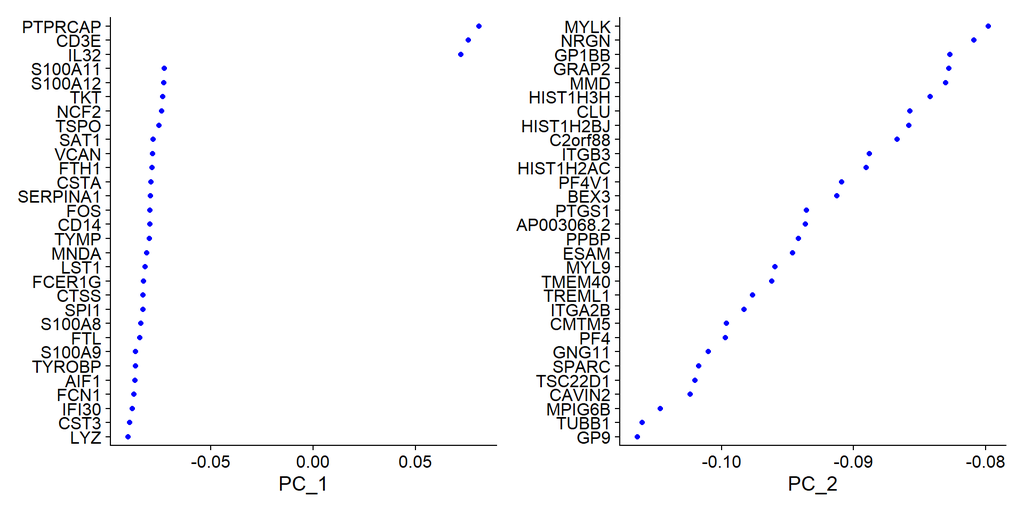

```r
> VizDimLoadings(pbmc, dims =1:2, reduction ="pca")
```

### DimPlot方法

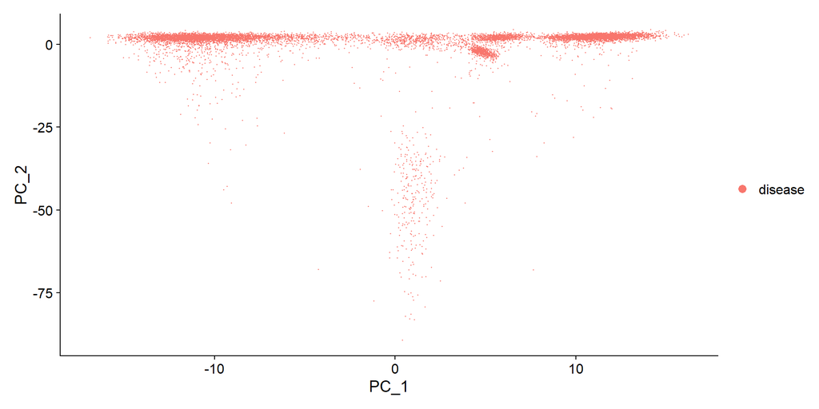

```r
> DimPlot(pbmc, reduction ="pca")
```

### DimHeatmap方法

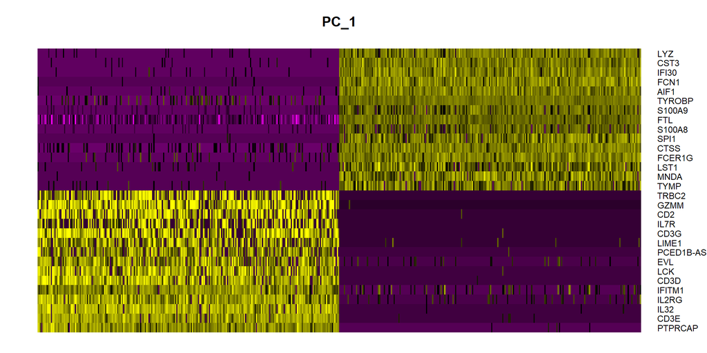

```r
> DimHeatmap(pbmc, dims =1, cells =500, balanced =TRUE)
```

### 输出PC1至PC15

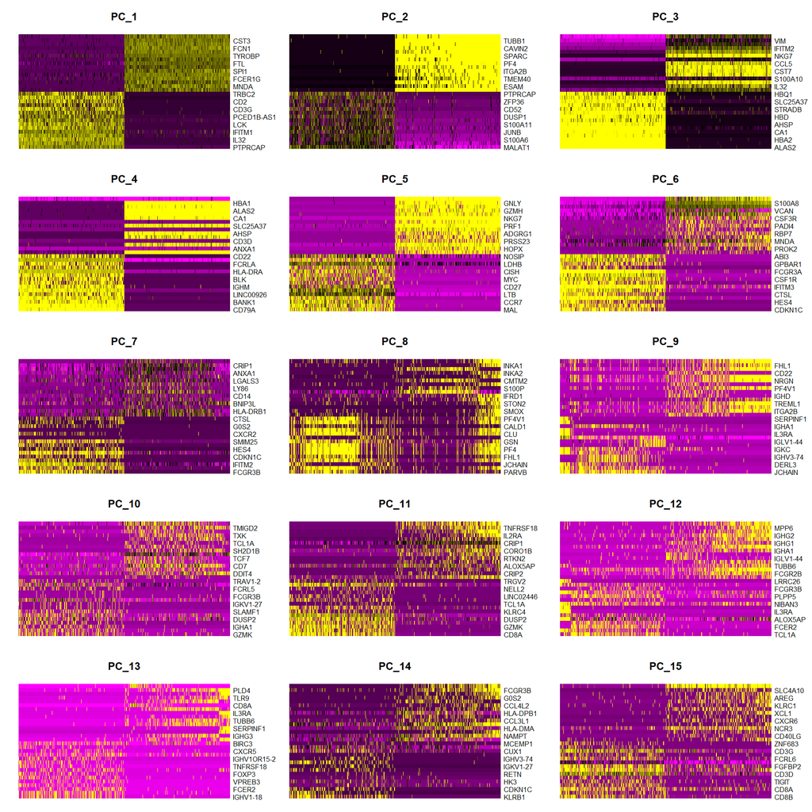

```r
> DimHeatmap(pbmc, dims =1:15, cells =500, balanced =TRUE)
```

### 确定数据集的“维度”

NOTE:This process can take a long time for big datasets, comment out for expediency. More approximate techniques such as those implemented in ElbowPlot() can be used to reduce computation time 翻译：注意:对于大数据集，这个过程可能需要很长时间,本次分析使用了5分钟 可以使用更近似的技术(如ElbowPlot()中实现的技术)来减少计算时间

#### JackStraw函数

在JackStraw()函数中, 使用基于零分布的置换检验方法。随机抽取一部分基因(默认1%)然后进行pca分析得到pca分数，将这部分基因的pca分数与先前计算的pca分数进行比较得到显著性p-Value，。根据主成分（pc）所包含基因的p-value进行判断选择主成分。最终的结果是每个基因与每个主成分的关联的p-Value。保留下来的主成分是那些富集小的p-Value基因的主成分。 JackStrawPlot()函数提供可视化方法，用于比较每一个主成分的p-value的分布，虚线是均匀分布；显著的主成分富集有小p-Value基因，实线位于虚线左上方。

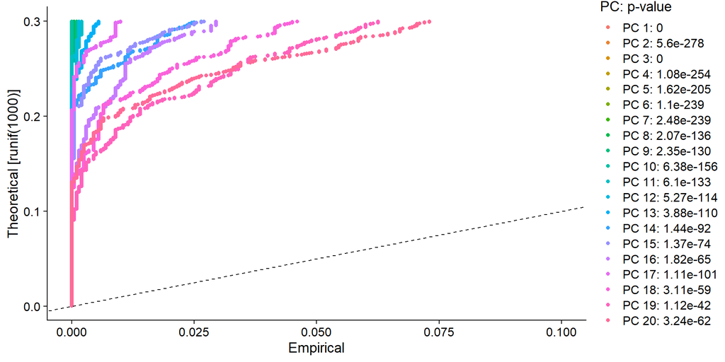

```r
> pbmc <- JackStraw(pbmc, num.replicate =100)
>
> pbmc <- ScoreJackStraw(pbmc, dims =1:20)
>
> JackStrawPlot(pbmc, dims =1:20)
```

#### ElbowPlot函数

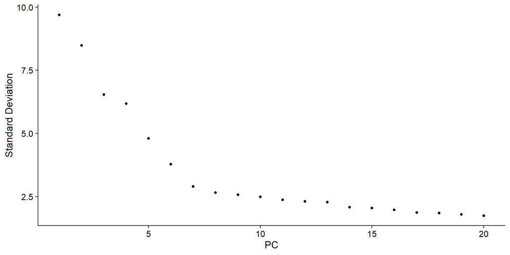

```r
> ElbowPlot(pbmc)
```

注意：鉴别数据的真实维度不是件容易的事情；除了上面两种方法，Serat官当文档还建议将主成分(数据异质性的相关来源有关)与GSEA分析相结合。

Serat官当文档因此鼓励用户使用不同数量的PC（10、15，甚至50）重复下游分析。其实也将观察到的，结果通常没有显著差异。因此，在选择此参数时，可以尽量选大一点的维度，维度太小的话对结果会产生不好的影响。

## 细胞聚类

Seurat v3应用基于图形的聚类方法，例如KNN方法。具有相似基因表达模式的细胞之间绘制边缘，然后将他们划分为一个内联群体。

在PhenoGraph中，首先基于pca维度中（先前计算的pca数据）计算欧式距离（the euclidean distance），然后根据两个细胞在局部的重合情况（Jaccard 相似系数）优化两个细胞之间的边缘权值。此步骤内置于FindNeighbors函数，输入时先前确定的pc数据。

为了聚类细胞，接下来应用模块化优化技术迭代将细胞聚集在一起。（the Louvain algorithm (default) or SLM [SLM, Blondel et al., Journal of Statistical Mechanics]），FindClusters函数实现这一功能，其中需要注意resolution参数，该参数设置下游聚类分析的“granularity”，更大的resolution会导致跟多的细胞类群。3000左右的细胞量，设置resolution为0.4-1.2是比较合适的。细胞数据集越大，需要更大的resolution参数, 会获得更多的细胞聚类。 查看细胞属于那个类群可以使用函数Idents。

```r
> pbmc <- FindNeighbors(pbmc, dims = 1:20)
> pbmc <- FindClusters(pbmc, resolution = 0.5)
```

```
Modularity Optimizer version 1.3.0 by Ludo Waltman and Nees Jan van Eck

Number of nodes: 10378
Number of edges: 378698

Running Louvain algorithm...
Maximum modularity in 10 random starts: 0.9223
Number of communities: 20
Elapsed time: 0 seconds
```

```r
> head(Idents(pbmc), 5)
```

```
AAACCTGAGACAAAGG-1 AAACCTGAGATGCGAC-1 AAACCTGAGCTGGAAC-1 AAACCTGAGGATGGTC-1
                 3                  0                  5                  5
AAACCTGCAATTGCTG-1
                 1
Levels: 0 1 2 3 4 5 6 7 8 9 10 11 12 13 14 15 16 17 18 19
```

## 非线性降维分析

Seurat提供了一些非线性降维度分析的方法，如tSNE和UMAP，以可视化和探索这些数据集；这一步使用的数据建议与聚类分析使用的pc维度一致。

使用uMAP方法进行降维分析

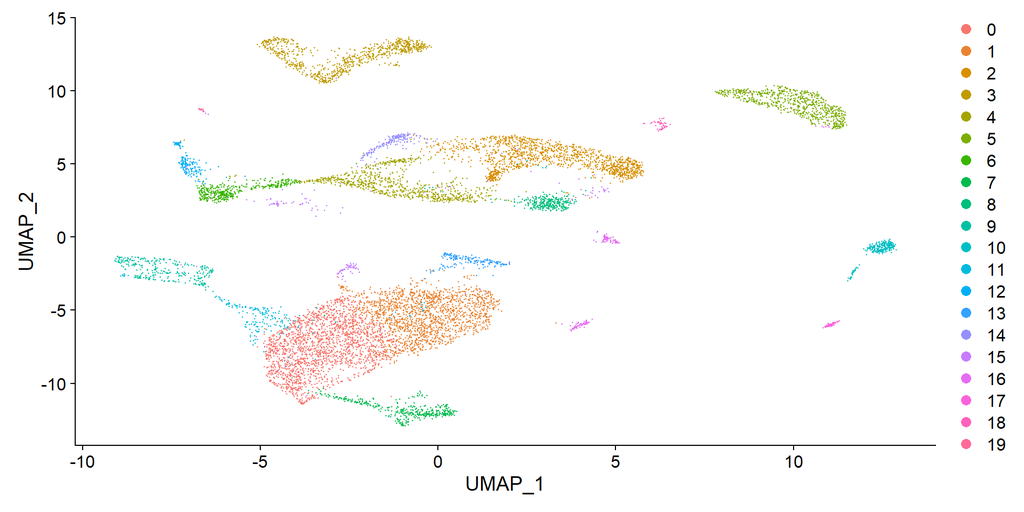

```r
> pbmc_PCA <- RunUMAP(pbmc, dims =1:20)
>
> DimPlot(pbmc_PCA, reduction ="umap")
```

### 添加细胞类群xiba的标签

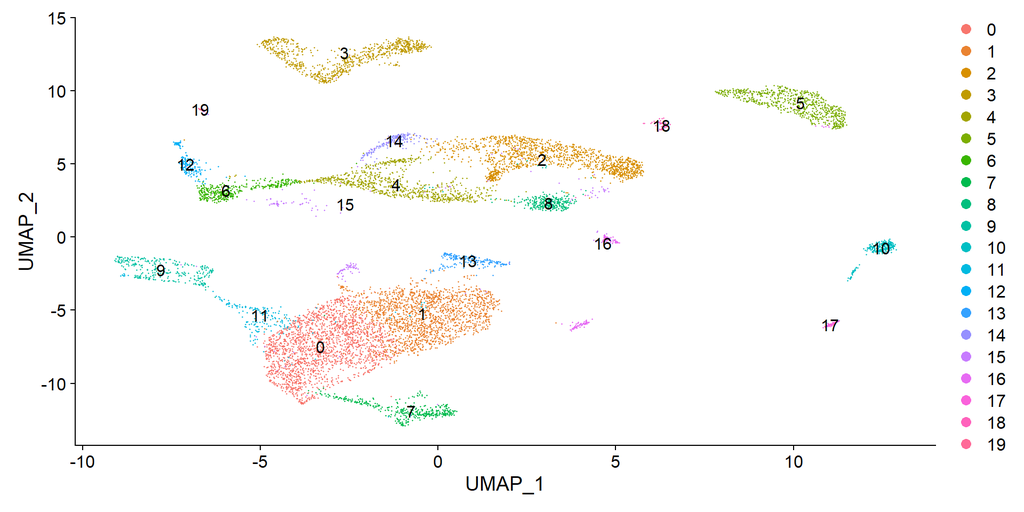

```r
> DimPlot(pbmc_PCA, reduction = "umap",label = TRUE)
```

```r
> #或者使用
> #LabelClusters(DimPlot(pbmc_PCA, reduction = "umap"),id = 'ident')
```

```r
> saveRDS(pbmc_PCA, file ="result/normal/pbmc_tutorial.rds")
```

## 寻找差异表达的特征（聚类生物标志物）

Seurat可以通过差异表达分析寻找不同细胞类群的标记基因。FindMarkers函数可以进行此操作，但是默认寻找单个类群(参数ident.1)与其他所有类群阳性和阴性标记基因。FindAllMarkers函数会自动寻找每个类群和其他每个类群之间的标记基因。

min.pct参数:设定在两个细胞群中任何一个被检测到的百分比，通过此设定不检测很少表达基因来缩短程序运行时间。默认0.1

thresh.test参数：设定在两个细胞群中基因差异表达量。可以设置为0 ，程序运行时间会更长。

max.cells.per.ident参数：每个类群细胞抽样设置；也可以缩短程序运行时间。

寻找cluster1中的标志物

```r
> cluster1.markers <- FindMarkers(pbmc_PCA, ident.1 =1, min.pct =0.25)
>
> head(cluster1.markers, n =5)
```

```
        p_val avg_log2FC pct.1 pct.2 p_val_adj
PGD         0   1.307898 0.754 0.353         0
CSF3R       0   1.307985 0.708 0.256         0
S100A11     0   1.081487 0.976 0.686         0
S100A9      0   2.655140 0.990 0.499         0
S100A12     0   2.547759 0.945 0.292         0
```

输出结果至csv文件

```r
> write.csv(cluster1.markers,file = "result/normal/cluster1.markers.csv")
```

找出每个细胞簇的标记物，与所有剩余的细胞进行比较，只报告阳性细胞

```r
> pbmc.markers <- FindAllMarkers(pbmc_PCA, only.pos = TRUE, min.pct = 0.25, logfc.threshold = 0.25)
> pbmc.markers %>% group_by(cluster) %>% top_n(n = 2, wt = avg_log2FC)
```

```
# A tibble: 40 x 7
# Groups:   cluster [20]
   p_val avg_log2FC pct.1 pct.2 p_val_adj cluster gene
   <dbl>      <dbl> <dbl> <dbl>     <dbl> <fct>   <chr>
 1     0       1.97 0.845 0.143         0 0       LGALS2
 2     0       1.85 0.997 0.37          0 0       LYZ
 3     0       2.66 0.99  0.499         0 1       S100A9
 4     0       2.65 0.994 0.453         0 1       S100A8
 5     0       2.30 0.979 0.334         0 2       LTB
 6     0       2.15 0.891 0.165         0 2       IL7R
 7     0       4.23 0.985 0.023         0 3       CD79A
 8     0       3.85 0.982 0.015         0 3       MS4A1
 9     0       2.84 0.58  0.051         0 4       GZMK
10     0       2.55 0.745 0.064         0 4       CD8A
# ... with 30 more rows
```

输出结果至CSV文件

```r
> write.table(pbmc.markers,file = 'pbmc.markers.csv')
```

Seurat也可以通过参数test.use设定检验差异表达的方法

## 可视化标记基因

1.VlnPlot: 基于细胞类群的基因表达概率分布 2.FeaturePlot：在tSNE 或 PCA图中画出基因表达情况 3.RidgePlot，CellScatter，DotPlot

使用S100A9和HBB举例

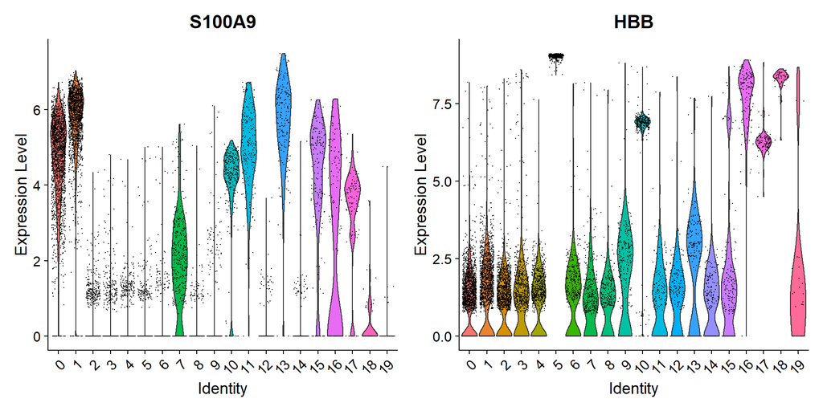

```r
> VlnPlot(pbmc, features = c("S100A9", "HBB"))
```

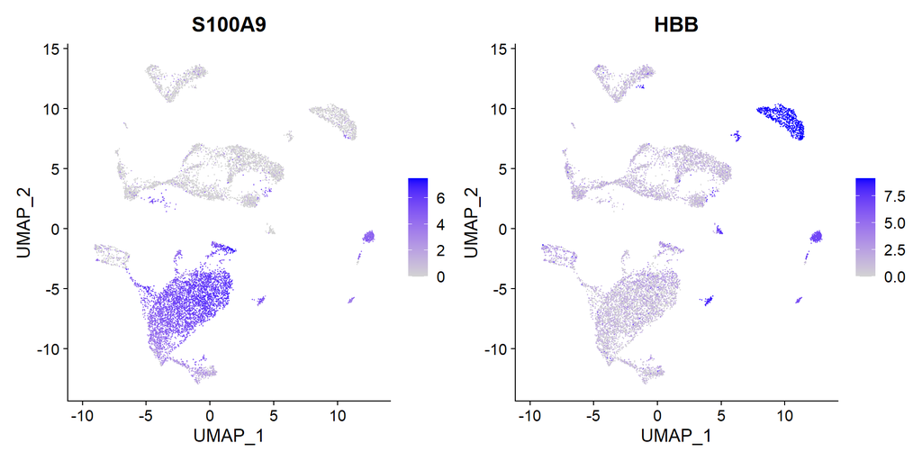

```r
> FeaturePlot(pbmc_PCA, features = c("S100A9","HBB"))
```

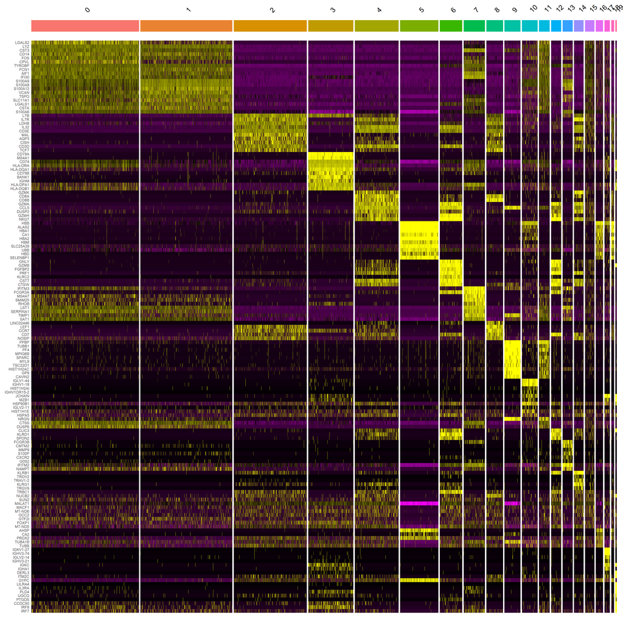

```r
> top10 <- pbmc.markers %>% group_by(cluster) %>% top_n(n = 10, wt = avg_log2FC)
> DoHeatmap(pbmc_PCA, features = top10$gene) + NoLegend()
```

## 确定细胞聚类簇的种类

根据不同的mark基因，即可确定细胞聚类簇的种类，关于不同细胞的mark基因，可在CellMarker网站上进行查询，进行人为标注。另外，也有基于生物信息学的客观的亚群鉴定方法（R包SingleR和celaref），但因可用的细胞亚型转录本缺乏，并未得到推广

```r
> #举例说明，细胞种类名称请按照聚类簇的正确对照填写
> new.cluster.ids <- c("Naive CD4 T", "Memory CD4 T", "CD14+ Mono", "B", "CD8 T", "FCGR3A+ Mono",
+     "NK", "DC", "Platelet")
> names(new.cluster.ids) <- levels(pbmc)
> pbmc <- RenameIdents(pbmc, new.cluster.ids)
> DimPlot(pbmc, reduction = "umap", label = TRUE, pt.size = 0.5) + NoLegend()
```

[output not shown]